# Как тип задания влияет на число попыток и время взаимодействия с заданием

```r
wd <- getwd()
assignments <- fread("unzip -cq ../data/assignments.zip")  %>%
  mutate(course_item_type_desc = factor(course_item_type_desc), vis_b = ifelse(vis_tw==0, 0, 1)) %>%
  group_by(course_item_id) %>%
  mutate(difficulty =  sum(first_attempt == 0) / n()) %>%
  ungroup()
```

## 0. Об отчете

### Исследовательские вопросы

1. Как разные типы заданий влияют на количество попыток?
2. Как разные типы заданий влияют на время взаимодействия с заданием?

### Описание баз данных и ее переменных

1. База состоит из 49 курсов. У 9 курсов есть одновременно тесты и задания по программированию, я называю их *парные курсы*.
2. Полная база - все 49 курсов. База парных курсов - 9 курсов
3. Рассматриваются только задания, с которыми студенты справились.
4. Рассматриваются только студенты, которые закончили курс.
5. Рассматриваются два типа заданий: тест и задание по программированию.
6. Не рассматриваются тесты внутри видео.

### Переменные

- **attempts** - Попытки за задание. Сколько попыток этот студент сделал при решении этого задания;
- **assessment_id** - токен задания;
- **hse_user_id** - токен студента;
- **course_item_type_desc** - тип задания;
  - *lecture* - тест в видео (исключаю из анализа);
  - *test* - тест;
  - *programming* - задание по программированию;
- **difficulty** - сложность = число проваленных ошибок за задание, число студентов решавших это задание.
- **vis_b** - заходил студент на форум во время взаимодействия с заданием или нет?

## 1. Попытки

#### Анализ распределения

Для наглядности рассчитаем медиану числа попыток по курсу для заданий по программированию и для тестов:

Без учета вариации между курсами:

```r
assignments %>% group_by(course_item_type_desc) %>% summarise(attempts_vis_tw_median = median(attempts), attempts_vis_tw_mean = median(attempts))
```

```
## # A tibble: 2 x 3
##   course_item_type_desc attempts_vis_tw_median attempts_vis_tw_mean
##   <fct>                                  <int>                <int>
## 1 programming                                1                    1
## 2 quiz                                       1                    1
```

С учетом вариации между курсами:

```r
assignments %>% group_by(course_name, course_item_type_desc) %>% summarise(attempts_median = median(attempts), attempts_mean = mean(attempts)) %>% group_by(course_item_type_desc) %>% summarise(attempts_vis_tw_median = median(attempts_median), attempts_vis_tw_mean = median(attempts_mean))
```

```
## # A tibble: 2 x 3
##   course_item_type_desc attempts_vis_tw_median attempts_vis_tw_mean
##   <fct>                                  <dbl>                <dbl>
## 1 programming                                2                 2.83
## 2 quiz                                       2                 2.31
```

```r
summary(assignments$attempts)
```

```
##    Min. 1st Qu.  Median    Mean 3rd Qu.    Max.
##    1.00    1.00    1.00    1.98    2.00  431.00
```

```r
table(assignments$attempts)
```

```
##
##      1      2      3      4      5      6      7      8      9     10     11
## 741528 259207 122094  51821  28206  17647  10443   6878   4838   3323   2483
##     12     13     14     15     16     17     18     19     20     21     22
##   1975   1422   1096    867    767    508    472    369    335    270    198
##     23     24     25     26     27     28     29     30     31     32     33
##    200    166    154    128    121     96     79     59     55     47     56
##     34     35     36     37     38     39     40     41     42     43     44
##     46     33     39     23     29     23     24     19     10     17     17
##     45     46     47     48     49     50     51     52     53     54     55
##     16     12      9      6      8      8      7      8      4      9      7
##     56     57     58     59     60     61     62     63     64     65     66
##      6      4      5      7      5      6      5      3      4      1      2
##     67     68     69     70     71     72     74     76     77     78     79
##      3      1      4      3      2      3      4      2      1      1      1
##     80     82     85     86     87     88     89     90     96     99    100
##      1      1      1      1      3      1      1      2      1      2      1
##    101    108    111    112    114    115    119    124    125    127    165
##      1      1      1      1      1      1      1      2      1      1      1
##    167    171    177    194    209    245    372    431
##      1      1      1      1      1      1      1      1
```

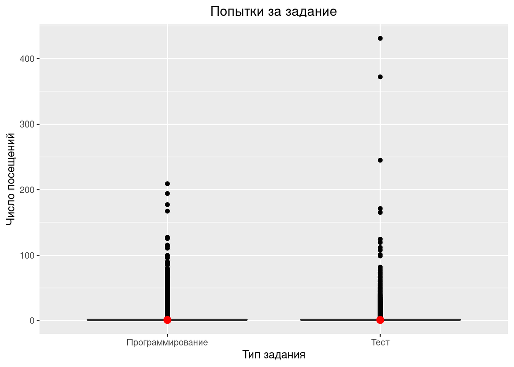

```r
assignments  %>% ggplot(aes(x = course_item_type_desc, y = attempts)) + geom_boxplot() +
  geom_point() +
  scale_x_discrete(labels=c("Программирование", "Тест")) + stat_summary(fun.y = "median", color = "red",  size = 3, geom = "point") +
  labs(x = "Тип задания", y = "Число посещений") + ggtitle("Попытки за задание") + theme(plot.title = element_text(hjust = 0.5))
```

#### Тест Манна-Уитни

```r
wilcox.test(attempts ~ course_item_type_desc, assignments)
```

```
##
##  Wilcoxon rank sum test with continuity correction
##
## data:  attempts by course_item_type_desc
## W = 1.6726e+11, p-value < 2.2e-16
## alternative hypothesis: true location shift is not equal to 0
```

```r
assignments %>% ungroup() %>% wilcox_effsize(attempts ~ course_item_type_desc)
```

```
## # A tibble: 1 x 7
##   .y.      group1      group2 effsize     n1     n2 magnitude
## * <chr>    <chr>       <chr>    <dbl>  <int>  <int> <ord>
## 1 attempts programming quiz    0.0992 778577 479813 small
```

#### Анализ распределения

```r
m0p <- glmer(attempts ~ 1 + (1|course_name), family = "poisson",
            assignments)
dispersion_glmer(m0p)
```

```
## [1] 1.085853
```

```r
m0 <- glmer(attempts ~ 1 + (1|course_name), family = "poisson",
            assignments)
summary(m0)
```

```
## Generalized linear mixed model fit by maximum likelihood (Laplace
##   Approximation) [glmerMod]
##  Family: poisson  ( log )
## Formula: attempts ~ 1 + (1 | course_name)
##    Data: assignments
##
##      AIC      BIC   logLik deviance df.resid
##  4498938  4498962 -2249467  4498934  1258388
##
## Scaled residuals:
##     Min      1Q  Median      3Q     Max
##  -1.856  -0.603  -0.586   0.140 186.079
##
## Random effects:
##  Groups      Name        Variance Std.Dev.
##  course_name (Intercept) 0.114    0.3376
## Number of obs: 1258390, groups:  course_name, 49
##
## Fixed effects:
##             Estimate Std. Error z value Pr(>|z|)
## (Intercept) 0.886656   0.008817   100.6   <2e-16 ***
## ---
## Signif. codes:  0 '***' 0.001 '**' 0.01 '*' 0.05 '.' 0.1 ' ' 1
## convergence code: 0
## Model failed to converge with max|grad| = 0.00529302 (tol = 0.002, component 1)
```

```
##
## Cреднее количество попыток за задание на среднем курсе: 2
```

```
## Эта вероятность будет колебаться между: 2 и 3.
```

#### Попытки и тип задания

```r
m1 <- glmer(attempts ~ course_item_type_desc + (1|course_name), family = "poisson",
            assignments)
summary(m1)
```

```
## Generalized linear mixed model fit by maximum likelihood (Laplace
##   Approximation) [glmerMod]
##  Family: poisson  ( log )
## Formula: attempts ~ course_item_type_desc + (1 | course_name)
##    Data: assignments
##
##      AIC      BIC   logLik deviance df.resid
##  4483721  4483757 -2241857  4483715  1258387
##
## Scaled residuals:
##     Min      1Q  Median      3Q     Max
##  -2.206  -0.603  -0.586   0.140 186.099
##
## Random effects:
##  Groups      Name        Variance Std.Dev.
##  course_name (Intercept) 0.1028   0.3206
## Number of obs: 1258390, groups:  course_name, 49
##
## Fixed effects:
##                            Estimate Std. Error z value Pr(>|z|)
## (Intercept)                1.234929   0.010196   121.1   <2e-16 ***
## course_item_type_descquiz -0.394137   0.003137  -125.6   <2e-16 ***
## ---
## Signif. codes:  0 '***' 0.001 '**' 0.01 '*' 0.05 '.' 0.1 ' ' 1
##
## Correlation of Fixed Effects:
##             (Intr)
## crs_tm_typ_ -0.005
```

```
##
## Количество попыток за задание по программированию: 3.44.
```

```
## Количество попыток за тесты: 2.32.
```

```
## Количество попыток за задание по программированию выше количества попыток за тест в 0.67 раз.
```

```r
#confint(m1)
```

## 2. Время выполнения задания

```r
summary(assignments$assignment_time)
```

```
##    Min. 1st Qu.  Median    Mean 3rd Qu.    Max.
##       0       4      13    6220     116 2199019
```

```r
tw <- assignments %>% filter(assignment_time < 116) # by 3d quantile
```

Без учета вариации между курсами:

```r
tw %>% group_by(course_item_type_desc) %>% summarise(assignment_time_vis_tw_median = median(assignment_time), assignment_time_vis_tw_mean = mean(assignment_time))
```

```
## # A tibble: 2 x 3
##   course_item_type_desc assignment_time_vis_tw_median assignment_time_vis_tw_me…
##   <fct>                                         <int>                      <dbl>
## 1 programming                                      10                       19.5
## 2 quiz                                              3                       10.1
```

```r
wilcox.test(assignment_time ~ course_item_type_desc, tw)
```

```
##
##  Wilcoxon rank sum test with continuity correction
##
## data:  assignment_time by course_item_type_desc
## W = 1.491e+11, p-value < 2.2e-16
## alternative hypothesis: true location shift is not equal to 0
```

```r
tw %>% ungroup() %>% wilcox_effsize(assignment_time ~ course_item_type_desc)
```

```
## # A tibble: 1 x 7
##   .y.             group1      group2 effsize     n1     n2 magnitude
## * <chr>           <chr>       <chr>    <dbl>  <int>  <int> <ord>
## 1 assignment_time programming quiz     0.333 561545 381693 moderate
```

### 2.1 Анализ распределения

```r
summary(tw$assignment_time)
```

```
##    Min. 1st Qu.  Median    Mean 3rd Qu.    Max.
##    0.00    2.00    7.00   15.68   19.00  115.00
```

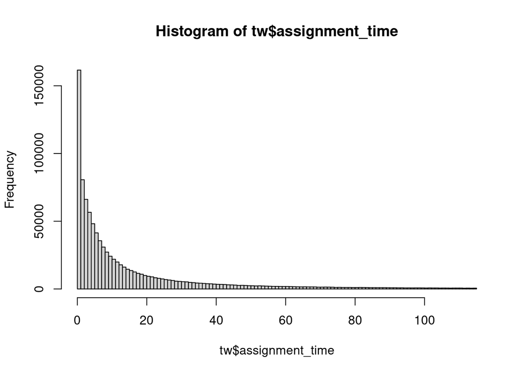

```r
hist(tw$assignment_time, breaks = 100)
```

```r
m0p <- glmer(assignment_time ~ 1 + (1|course_name), family = "poisson",
            tw)
dispersion_glmer(m0p)
```

```
## [1] 4.34815
```

```r
m0 <- glmer.nb(assignment_time ~ 1 + (1|course_name),
            tw)
dispersion_glmer(m0)
```

```
## [1] 1.065014
```

```r
summary(m0)
```

```
## Generalized linear mixed model fit by maximum likelihood (Laplace
##   Approximation) [glmerMod]
##  Family: Negative Binomial(0.8053)  ( log )
## Formula: assignment_time ~ 1 + (1 | course_name)
##    Data: tw
##
##      AIC      BIC   logLik deviance df.resid
##  6915494  6915529 -3457744  6915488   943235
##
## Scaled residuals:
##     Min      1Q  Median      3Q     Max
## -0.8878 -0.6926 -0.4598  0.1455 30.0811
##
## Random effects:
##  Groups      Name        Variance Std.Dev.
##  course_name (Intercept) 0.3253   0.5704
## Number of obs: 943238, groups:  course_name, 49
##
## Fixed effects:
##             Estimate Std. Error z value Pr(>|z|)
## (Intercept)  2.78463    0.01993   139.7   <2e-16 ***
## ---
## Signif. codes:  0 '***' 0.001 '**' 0.01 '*' 0.05 '.' 0.1 ' ' 1
```

```
##
## Cреднее количество минут за задание на среднем курсе: 16
```

```
## Эта вероятность будет колебаться между: 9 и 29.
```

### 2.2 Время выполнения задания и тип задания

```r
m1 <- glmer.nb(assignment_time ~ course_item_type_desc + (1|course_name), tw)
summary(m1)
```

```
## Generalized linear mixed model fit by maximum likelihood (Laplace
##   Approximation) [glmerMod]
##  Family: Negative Binomial(0.8258)  ( log )
## Formula: assignment_time ~ course_item_type_desc + (1 | course_name)
##    Data: tw
##
##      AIC      BIC   logLik deviance df.resid
##  6890250  6890297 -3445121  6890242   943234
##
## Scaled residuals:
##     Min      1Q  Median      3Q     Max
## -0.9011 -0.7010 -0.4654  0.1648 30.3803
##
## Random effects:
##  Groups      Name        Variance Std.Dev.
##  course_name (Intercept) 0.3686   0.6071
## Number of obs: 943238, groups:  course_name, 49
##
## Fixed effects:
##                            Estimate Std. Error z value Pr(>|z|)
## (Intercept)                4.037969   0.018272   221.0   <2e-16 ***
## course_item_type_descquiz -1.389419   0.009272  -149.9   <2e-16 ***
## ---
## Signif. codes:  0 '***' 0.001 '**' 0.01 '*' 0.05 '.' 0.1 ' ' 1
##
## Correlation of Fixed Effects:
##             (Intr)
## crs_tm_typ_ -0.047
```

```
##
## Количество минут на задание по программированию: 56.71.
```

```
## Количество минут за тесты: 14.13.
```

```
## Длительность задание по программированию дольше теста в 0.25 раз.
```

## 3. Сложность и тип задания

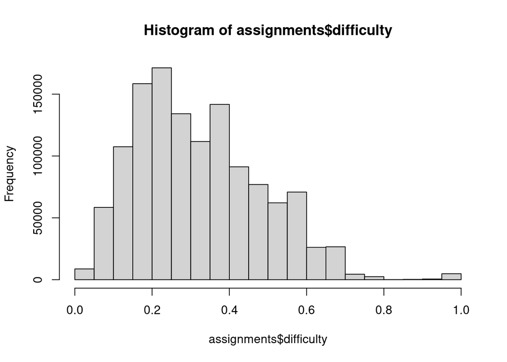

```r
hist(assignments$difficulty)
```

```r
m1 <- glmer(difficulty ~ course_item_type_desc + (1|course_name), family = "binomial", assignments)
summary(m1)
```

```
## Generalized linear mixed model fit by maximum likelihood (Laplace
##   Approximation) [glmerMod]
##  Family: binomial  ( logit )
## Formula: difficulty ~ course_item_type_desc + (1 | course_name)
##    Data: assignments
##
##       AIC       BIC    logLik  deviance  df.resid
## 1059283.9 1059320.0 -529638.9 1059277.9   1258387
##
## Scaled residuals:
##     Min      1Q  Median      3Q     Max
## -0.4390  0.1071  0.4242  0.8238  2.9340
##
## Random effects:
##  Groups      Name        Variance Std.Dev.
##  course_name (Intercept) 0        0
## Number of obs: 1258390, groups:  course_name, 49
##
## Fixed effects:
##                            Estimate Std. Error z value Pr(>|z|)
## (Intercept)               -1.357704   0.002791  -486.4   <2e-16 ***
## course_item_type_descquiz -1.069022   0.005969  -179.1   <2e-16 ***
## ---
## Signif. codes:  0 '***' 0.001 '**' 0.01 '*' 0.05 '.' 0.1 ' ' 1
##
## Correlation of Fixed Effects:
##             (Intr)
## crs_tm_typ_ -0.466
## convergence code: 0
## boundary (singular) fit: see ?isSingular
```

```
##
## Сложность задания по программированию: 0.20.
```

```
## Сложность теста: 0.08.
```

```
## Сложность задания по программированию больше теста в 0.26 раз.
```